# Sorites Prior Elicitation 2C: 3 domains

## Experiment Design

There were 3 domains (height, price, and age) corresponding to 3 adjectives (tall, expensive, old). For each domain, there were 3 items (height: building, tree, mountain; price: watch, laptop, coffee maker; age: New Yorker, college student, new parent).

For height items, there were 20 bins per item. For age items, there were 18 bins per item. For prices, the number of bins varied (we were attempting to accommodate the tails of the distributions, based on pilot prior elicition).

The width of the bins (e.g. 1000 for “A mountain with a height between 1000 and 2000 ft”) varied according to the type of item. Ages were always in bins of width 5.

```
##              item domain bin.width nbins
## 1 college student    age         5    18
## 2      new parent    age         5    18
## 3      New Yorker    age         5    18
## 4            tree height         5    20
## 5        building height        10    20
## 6        mountain height      1000    20
## 7    coffee maker  price         4    68
## 8           watch  price        50    60
## 9          laptop  price        50    50
```

We had prior (no utterance) and posterior (someone says, “that [[item]] is [[adjective]]”“) conditions. Prior/posterior and domain were varied between Ss. There were at least 36 participants in each condition.

```
##   domain condition  N
## 1    age posterior 58
## 2    age     prior 78
## 3 height posterior 49
## 4 height     prior 59
## 5  price posterior 40
## 6  price     prior 36
```

## Empirical Priors and Posteriors

We normalize each participants response to each item to get an estimate of their discrete probability distribution for that item.

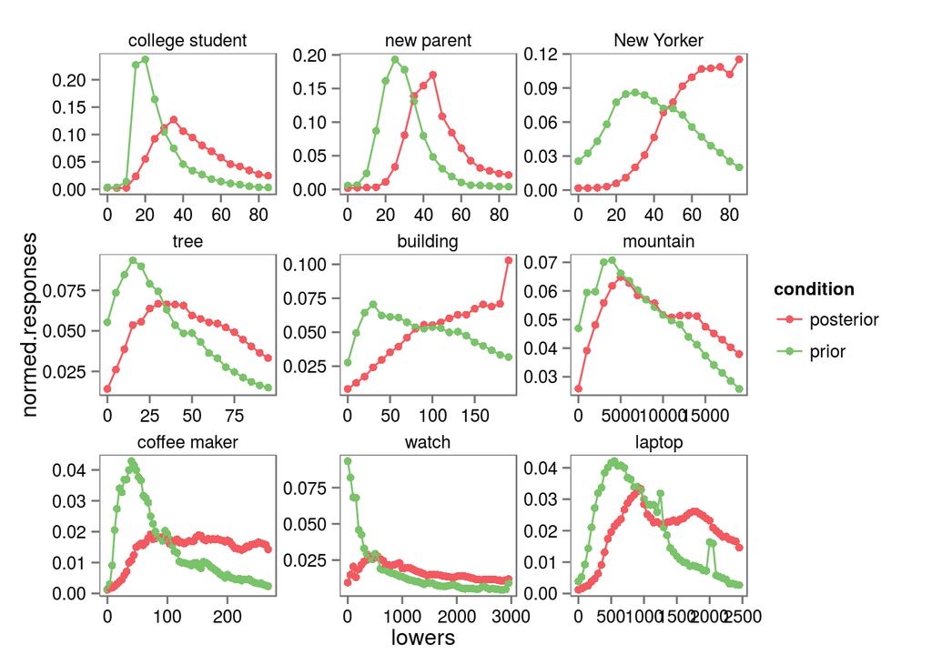

### Fit to Log-normal curve

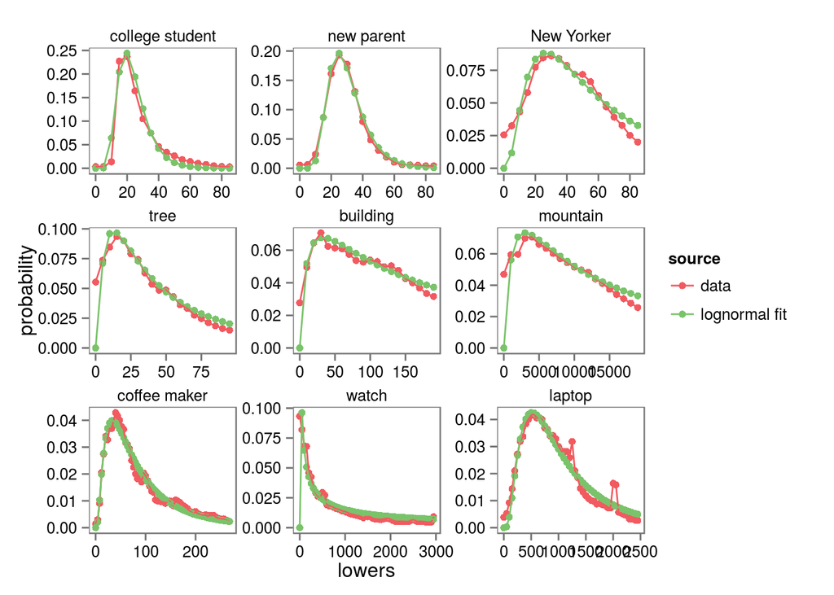

We plug the best-fit log-normal parameters into the adjectives model as the priors for the items.

```
##              item     mu   sig
## 1 college student   2.95 0.394
## 2      new parent   3.20 0.385
## 3      New Yorker   3.28 0.830
## 4            tree   2.53 1.146
## 5        building   3.49 1.612
## 6        mountain   7.99 1.479
## 7    coffee maker   3.51 0.871
## 8           watch -11.19 5.184
## 9          laptop   6.25 0.752
```